## Election Forecasting

### Bayesian Approach

Pollsters tend to make probabilistic statements about the results of the election. “The chance that Obama wins the electoral college is 91%” is a probabilistic statement about the parameter $d$. We showed that for the 2016 election, Fivethirtyeight gave Clinton an 81.4% chance of winning the popular vote. To do this they used the Bayesian approach we described.

We assume a hierarchical model similar to what we did to predict the performance of a baseball player.

Statistical textbooks will write the model like this:
$$\begin{aligned}
d &\sim N(\mu, \tau^2) \mbox{ describes our best guess had we not seen any polling data}\\
\bar{X} \mid d &\sim N(d, \sigma^2) \mbox{ describes randomness due to sampling and the pollster effect}
\end{aligned}$$

For our best guess we note that before any poll data is available we can use data sources other than polling data. A popular approach is to use what are called *fundamentals* which are based on properties about the current economy that historically appear to have an effect in favor or against the incumbent party. We won’t use these here. Instead we will use $\mu = 0$ which is interpreted as a model that simply does not provide any information on who will win. For the standard deviation we will use recent historical data that shows the winner of the popular vote has an average spread of about 3.5%. Therefore we set $\tau = 0.035$.

Now we can use the formulas for the posterior distribution for the parameter $d$: the probability of $d>0$ given the observed poll data:

```r
mu    <- 0
tau   <- 0.035
sigma <- results$se
Y     <- results$avg
B     <- sigma^2 / (sigma^2 + tau^2)

posterior_mean <- B*mu + (1-B)*Y
posterior_se   <- sqrt(1/ (1/sigma^2 + 1/tau^2))

posterior_mean
```

```
## [1] 0.02808534
```

```r
posterior_se
```

```
## [1] 0.006149604
```

To make a probability statement we use the fact that the posterior distribution is also normal. And we have a credible interval of

```r
posterior_mean + c(-1.96, 1.96)*posterior_se
```

```
## [1] 0.01603212 0.04013857
```

The posterior probability $\mbox{Pr}(d>0 \mid \bar{X})$ is

```r
1 - pnorm(0, posterior_mean, posterior_se)
```

```
## [1] 0.9999975
```

This says we are 100% sure Clinton will win the popular vote which seems overconfident. Also, it is not in agreement with Fivethirtyeight’s 81.4%. What explains this difference?

### The general bias

After elections are over, one can look at the difference between pollster predictions and the actual result. An important observation that our model does not take into account, is that it is common to see the general bias that affects many pollsters in the same way. There is no good explanation for this, but we do observe it in historical data: in one election the average of polls favor democrats by 2%, in the next election they favor republicans by 1%, then in the next there is no bias, then in the next republicans are favored by 3%, and so on. In 2016 the polls were biased in favor of the democrats by 1-2%.

Although we know this bias term affects our polls, we have no way of knowing what this bias is until election. So we can’t correct our polls accordingly. What we can do is include a term in our model that accounts for this variability.

### Mathematical representations of models

Suppose we are collecting data from one pollster and we assume there is no general bias. The pollster collects several polls with a sample size of $N$ so we observe several measurements of the spread $X_1, \dots, X_J$. The theory tells us that these random variables have expected value $d$ and standard error $2 \sqrt{p(1-p)/N}$. For reasons that will become clear soon we can represent this model mathematically like this:

$$X_j = d + \varepsilon_j$$
we use the index $j$ to represent the different polls and we define $\varepsilon_j$ to be a random variable that explains the poll to poll variability introduced by sampling error. To do this we assume it has mean 0 and standard error $2 \sqrt{p(1-p)/N}$. If $d$ is 2.1 and the sample size for these polls was 2,000 we can simulate $J=6$ data points from this model like this:

```r
set.seed(3)
J <- 6
N <- 2000
d <- 0.021
p <- (d + 1)/2
X <- d + rnorm(J,0,2*sqrt(p*(1-p)/N))
```

Now suppose we have $J=6$ data points from $I=5$ different pollsters. To represent this we need two indexes, one for each pollster and one for the polls each pollster takes. We use $X_{ij}$ with $i$ representing the pollster and $j$ representing the $j$-th poll from that pollster. If we apply the same model we write

$$X_{i,j} = d + \varepsilon_{i,j}$$

To simulate data we now have to loop through the pollsters:

```r
I <- 5
J <- 6
N <- 2000
X <- sapply(1:I, function(i){
            d + rnorm(J, 0, 2*sqrt(p*(1-p)/N))
})
```

The simulated data

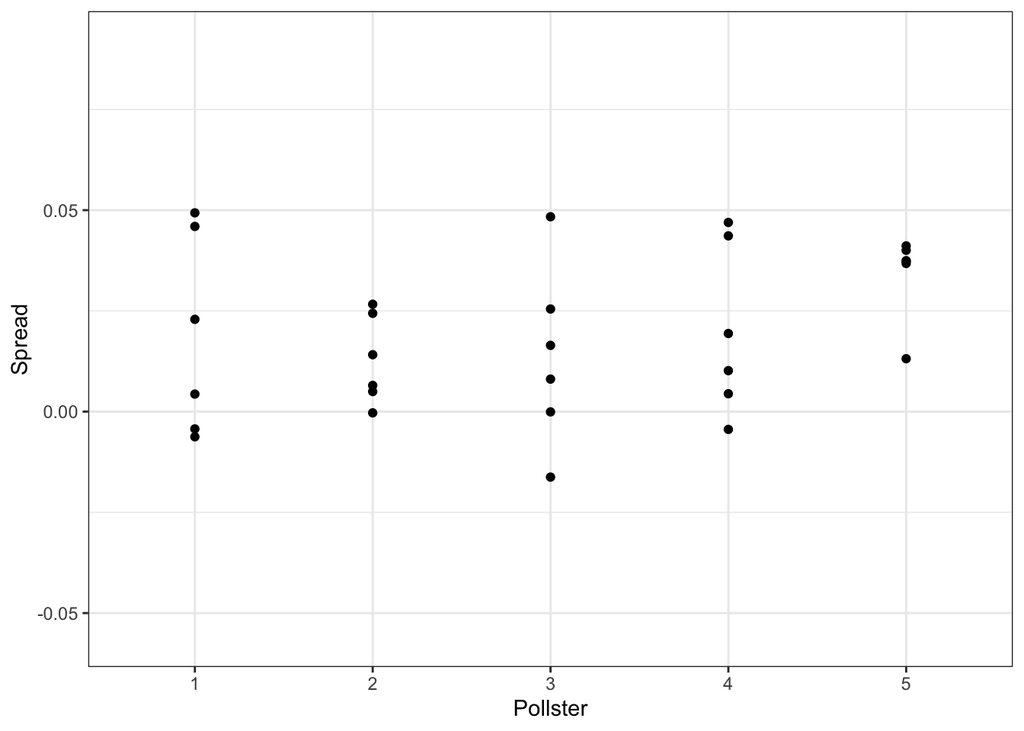

does not really seem to capture the features of the actual data

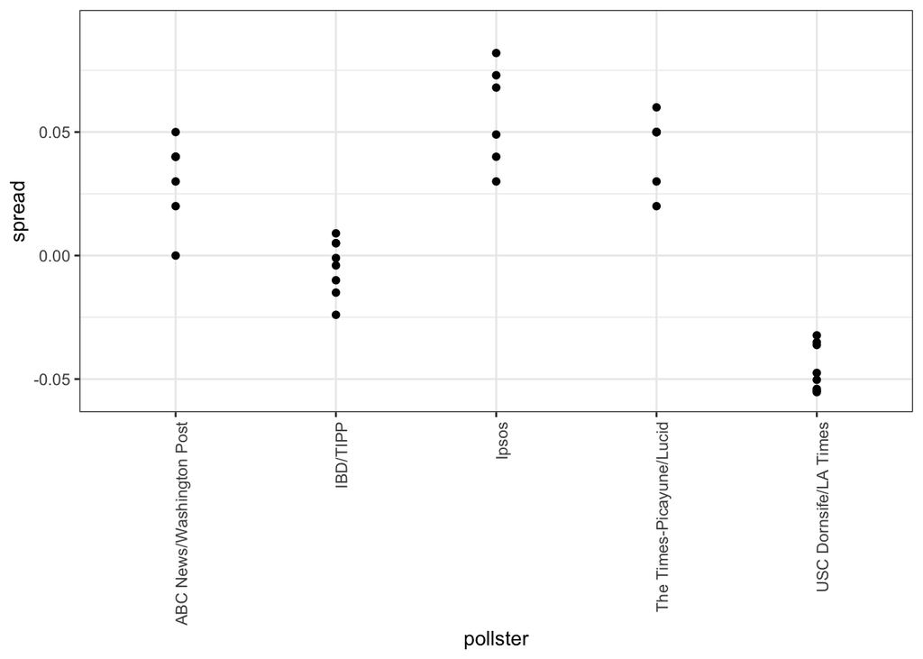

The model above does not account for pollster to pollster variability. To fix this we add a new term for the pollster effect. We will use $h_i$ to represent the house effect of the $i$-th pollster. The model is now augmented to

$$X_{i,j} = d + h_i + \varepsilon_{i,j}$$

To simulate data from a specific pollster we now need to draw an $h_i$ and then add the $\varepsilon$s. Here is how we would do it for one specific pollster. We assume $\sigma_h$ is 0.025:

```r
I <- 5
J <- 6
N <- 2000
d <- .021
p <- (d + 1)/2
h <- rnorm(I, 0, 0.025)
X <- sapply(1:I, function(i){
  d + h[i] + rnorm(J,0,2*sqrt(p*(1-p)/N))
})
```

The simulated data now looks more like the actual data:

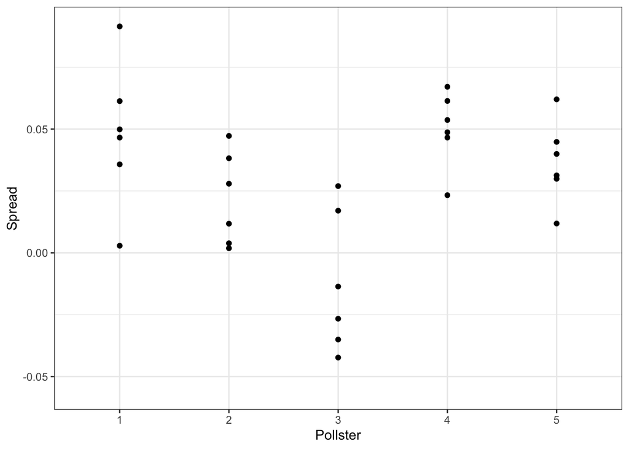

Note that $h_i$ is common to all the observed spreads from a specific pollster. Different pollsters have a different $h_i$ which explains why we can see the groups of points shift up and down from pollster to pollster.

Now, in the model above we assume the average house effect is 0. We think that for every pollster biased in favor of our party there is another favored for the other and assume the standard deviation is $\sigma_h$. But historically we see that every election has a general bias affecting all polls. We can observe this with the 2016 data, but if we collect historical data we see that the average of polls misses by more than what models like the one above predict. To see this we would take for each election year, the average of polls and compare it to the actual value. If we did this we would see a difference with standard deviation of between 2-3%. To incorporate this into the model we can add another term to account for this variability:
$$X_{ij} = d + b + h_i + \varepsilon_{ij}$$

and model $b$ as having expected value 0 and, based on historical data, assume the standard error for $b$ is $\sigma_b = 0.025$. Note that the variability of $b$ is not observed because every single poll we observe in 2016 has this general bias.

An implication of adding this term to the model is that the standard deviation for $X_{ij}$ is actually higher than what we earlier called $\sigma$, which combines the pollster variability and the sampling variability, and was estimated with:

```r
sd(one_poll_per_pollster$spread)
```

```
## [1] 0.02419369
```

since we have to add $\sigma_b$.

And note that

$$\bar{X} = d + b + \frac{1}{N}\sum_{i=1}^N \varepsilon_i$$

which implies that the standard deviation of $\bar{X}$ is

$$\sqrt{\sigma^2/N + \sigma_b^2}$$
Because the same $b$ is in every measurement, the average does not reduce its variance. This is an important point: **it does not matter how many polls you take; this bias does not get reduced**.

If we redo the Bayesian calculation taking this variability into account we get a result much closer to Fivethirtyeight:

```r
mu    <- 0
tau   <- 0.035
sigma <- sqrt(results$se^2 + .025^2)
Y     <- results$avg
B     <- sigma^2 / (sigma^2 + tau^2)

posterior_mean <- B*mu + (1-B)*Y
posterior_se   <- sqrt( 1/ (1/sigma^2 + 1/tau^2))

1 - pnorm(0, posterior_mean, posterior_se)
```

```
## [1] 0.8174373
```

### Predicting the electoral college

Up to now we have focused on the popular vote. But in the United States elections are not decided by the popular vote but rather what is called the electoral college. Each state gets a number of electoral votes that depends, in a somewhat complex way, on the population size of the state. Here are the top 5 states ranked by electoral votes:

```r
results_us_election_2016 %>% top_n(5, electoral_votes)
```

```
##          state electoral_votes clinton trump others
## 1   California              55    61.7  31.6    6.7
## 2        Texas              38    43.2  52.2    4.5
## 3      Florida              29    47.8  49.0    3.2
## 4     New York              29    59.0  36.5    4.5
## 5     Illinois              20    55.8  38.8    5.4
## 6 Pennsylvania              20    47.9  48.6    3.6
```

With some minor exceptions we don’t discuss, the electoral votes are won all or nothing. For example, if you win California by just 1 vote, you still get all 55 of its electoral votes. This means that by winning a few big states by a large margin but losing many small states by small margins, you can win the popular vote and lose the electoral college. This happened in 1876, 1888, 2000 and 2016. The idea behind this is to avoid a few large states having the power to dominate the presidential election. But many in the US consider the electoral college unfair and would like to see a change.

We are now ready to predict the electoral college result for 2016. We start by aggregating results from polls taken during the last week before the election:

```r
results <- polls_us_election_2016 %>%
  filter(state!="U.S." &
           !grepl("CD", state) &
           enddate >="2016-10-31" &
           (grade %in% c("A+","A","A-","B+") | is.na(grade))) %>%
  mutate(spread = rawpoll_clinton/100 - rawpoll_trump/100) %>%
  group_by(state) %>%
  summarize(avg = mean(spread), sd = sd(spread), n = n()) %>%
  mutate(state = as.character(state))
```

Here are the 10 closest races according to the polls:

```r
results %>% arrange(abs(avg))
```

```
## # A tibble: 47 x 4
##    state               avg     sd     n
##    <chr>             <dbl>  <dbl> <int>
##  1 Florida         0.00356 0.0163     7
##  2 North Carolina -0.00730 0.0306     9
##  3 Ohio           -0.0104  0.0252     6
##  4 Nevada          0.0169  0.0441     7
##  5 Iowa           -0.0197  0.0437     3
##  6 Michigan        0.0209  0.0203     6
##  7 Arizona        -0.0326  0.0270     9
##  8 Pennsylvania    0.0353  0.0116     9
##  9 New Mexico      0.0389  0.0226     6
## 10 Georgia        -0.0448  0.0238     4
## # … with 37 more rows
```

```r
results <- left_join(results, results_us_election_2016, by = "state")
```

Note that some states have no polls because the winner is pretty much known:

```r
results_us_election_2016 %>% filter(!state %in% results$state)
```

```
##                  state electoral_votes clinton trump others
## 1         Rhode Island               4    54.4  38.9    6.7
## 2               Alaska               3    36.6  51.3   12.2
## 3              Wyoming               3    21.9  68.2   10.0
## 4 District of Columbia               3    90.9   4.1    5.0
```

No polls were conducted in DC, Rhode Island, Alaska, and Wyoming because the first two are sure to be Democrats and the last two Republicans.

The code below assigns a standard deviation, the median of the rest, to states with just one poll.

```r
results <- results %>%
  mutate(sd = ifelse(is.na(sd), median(results$sd, na.rm=TRUE), sd))
```

To make probabilistic arguments we will use a Monte Carlo simulation. For each state we apply the Bayesian approach to generate an election day $d$. We could construct the priors for each state based on recent history. However, to keep it simple we assign a prior to each state that assumes we know nothing about what will happen. Because from election year to election year the results from a specific state don’t change that much we will assign a standard deviation of 2% or $\tau=0.02$. The Bayesian calculation looks like this:

```r
mu  <- 0
tau <- 0.02
results %>% mutate(sigma = sd/sqrt(n),
                   B = sigma^2 / (sd^2 + tau^2),
                   posterior_mean = B*mu + (1-B)*avg,
                   posterior_se = sqrt( 1/ (1/sigma^2 + 1/tau^2))) %>%
            arrange(abs(posterior_mean))
```

[output not shown]

Note that the estimates based on the posterior do move toward 0, although the states with many polls are influenced less. This is expected as the more poll data we collect the more we trust those results:

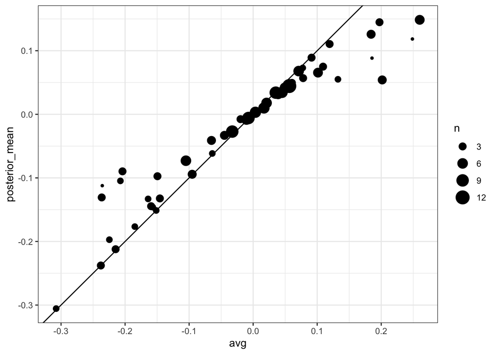

```r
results %>% mutate(sigma = sd/sqrt(n),
                   B = sigma^2 / (sigma^2 + tau^2),
                   posterior_mean = B*mu + (1-B)*avg,
                   posterior_se = sqrt( 1/ (1/sigma^2 + 1/tau^2))) %>%
  ggplot(aes(avg, posterior_mean, size = n)) + geom_point() +
  geom_abline(slope = 1, intercept = 0)
```

```r
mu  <- 0
tau <- 0.02
clinton_EV <- replicate(1000, {
  results %>% mutate(sigma = sd/sqrt(n),
                   B = sigma^2 / (sigma^2 + tau^2),
                   posterior_mean = B*mu + (1-B)*avg,
                   posterior_se = sqrt( 1/ (1/sigma^2 + 1/tau^2)),
                   simulated_result = rnorm(length(posterior_mean), posterior_mean, posterior_se),
                   clinton = ifelse(simulated_result > 0, electoral_votes, 0)) %>%
    summarize(clinton = sum(clinton)) %>%
    .$clinton + 7  ## 7 for Rhode Island and D.C.
})
mean(clinton_EV > 269)
```

```
## [1] 0.998
```

This model gives Clinton over 99% chance of winning. Here is a histogram of the possible outcomes:

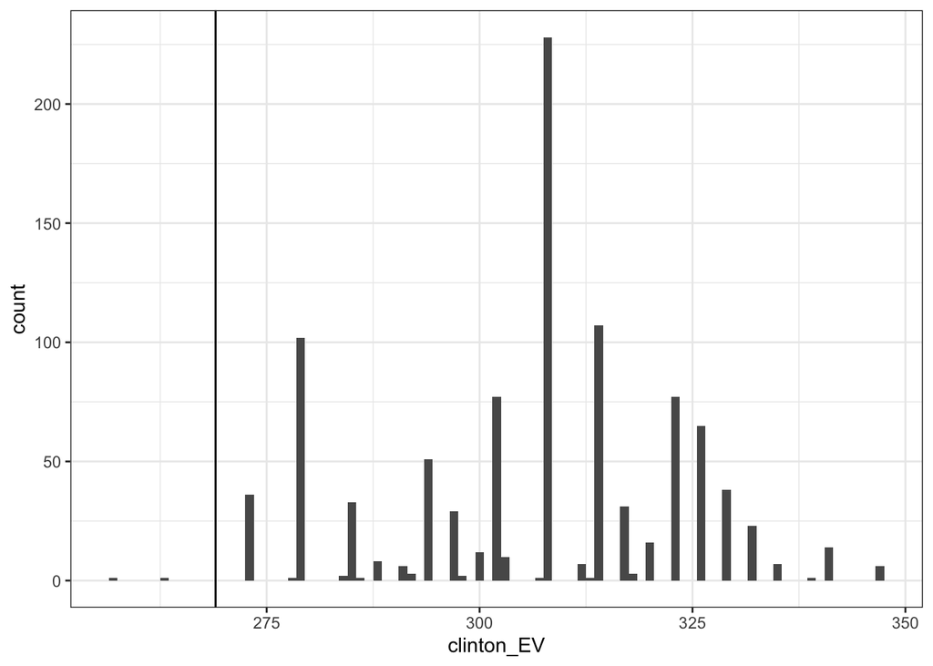

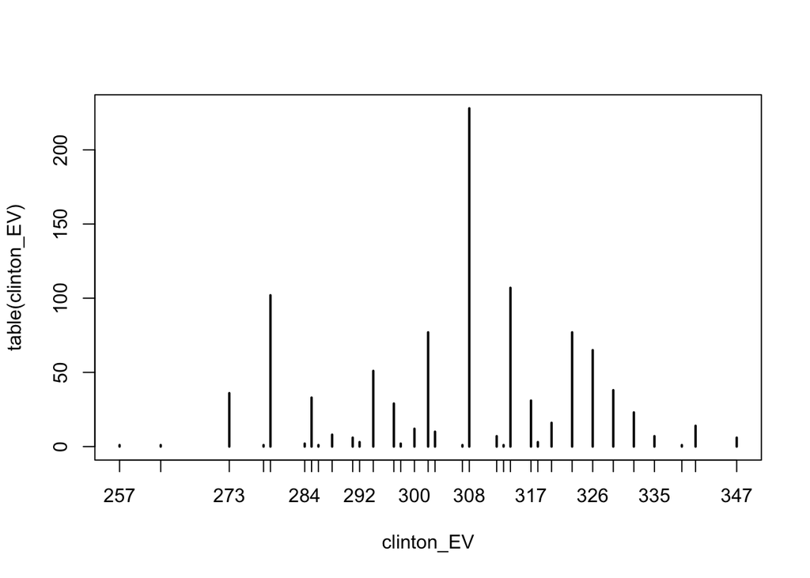

A similar prediction was made by the Princeton Election Consortium. We now know it was quite off. What happened?

Note that the model above ignores the general bias. The general bias in 2016 was not that big compared to other years: it was between 1 and 2%. But because the election was close in several big states, and the large number of polls made the estimates of standard errors small, and by ignoring the variability introduced by the general bias, pollsters were over confident on the poll data. Fivethirethyeight, which models the general bias in a rather sophisticated way, reported a closer result. We can simulate the results now with a bias term. For the state level the general bias can be larger so we set it at $\sigma_b = 0.03$:

```r
tau     <- 0.02
bias_sd <- 0.03
clinton_EV_2 <- replicate(1000, {
  results %>% mutate(sigma = sqrt(sd^2/n  + bias_sd^2),
                   B = sigma^2 / (sigma^2 + tau^2),
                   posterior_mean = B*mu + (1-B)*avg,
                   posterior_se = sqrt( 1/ (1/sigma^2 + 1/tau^2)),
                   simulated_result = rnorm(length(posterior_mean), posterior_mean, posterior_se),
                   clinton = ifelse(simulated_result>0, electoral_votes, 0)) %>%
    summarize(clinton = sum(clinton) + 7) %>% .$clinton ## add 7 for Rhode Island and D.C.
})
mean(clinton_EV_2 > 269)
```

```
## [1] 0.837
```

This gives us a much more sensible result.

Looking at the outcomes of the simulation we see how the bias term adds variability to the final results.

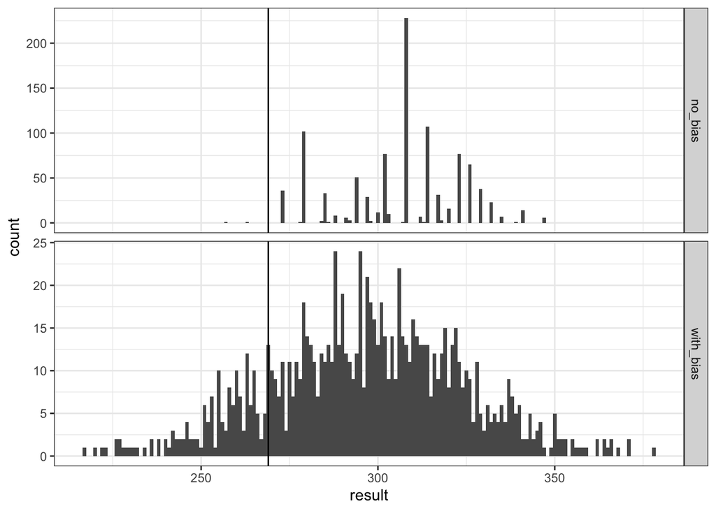

Fivethirtyeight includes many other features we do not include here. One is that they model variability with distributions that have high probabilities for extreme events compared to the normal. They predicted a probability of 71%.

### Forcasting

Forecasters like to make predictions well before the election. The predictions are adapted as new polls come out. However, an important question forecasters must ask is: how informative are polls taken several weeks before the election? Here we study the variability of poll results across time.

To make sure the variability we observe is not due to pollster effects, let’s study data from one pollster:

```r
one_pollster <- polls_us_election_2016 %>%
  filter(pollster == "Ipsos" & state == "U.S.") %>%
  mutate(spread = rawpoll_clinton/100 - rawpoll_trump/100)
```

Since there are no pollster effects, then perhaps the theoretical standard error matches the data-derived standard deviation. We compute both here:

```r
se <- one_pollster %>%
  summarize(empirical = sd(spread), theoretical = 2*sqrt(mean(spread)*(1-mean(spread))/min(samplesize)))
se
```

```
##    empirical theoretical
## 1 0.04025194  0.03256719
```

Note that the empirical standard deviation is higher than the highest possible theoretical estimate. Furthermore, the spread data does not look normal as the theory would predict:

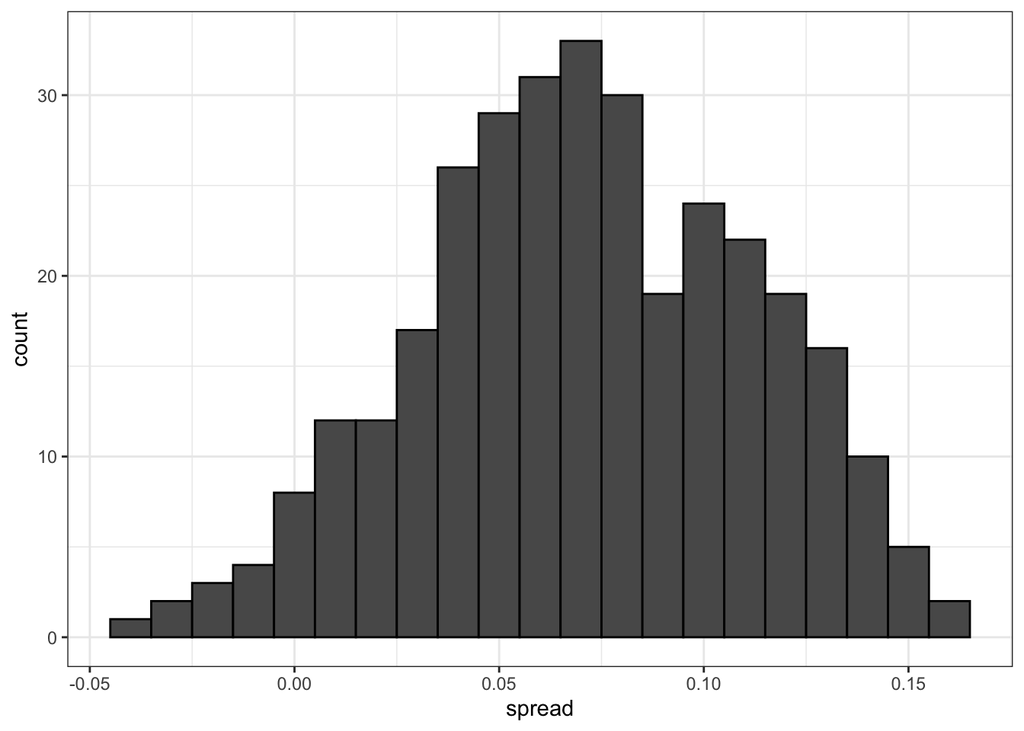

```r
one_pollster %>% ggplot(aes(spread)) +
  geom_histogram(binwidth = 0.01, color = "black")
```

Where is the extra variability coming from? The following plots make a strong case that the extra variability comes from time annunciations not accounted for by the theory that assumes $p$ is fixed:

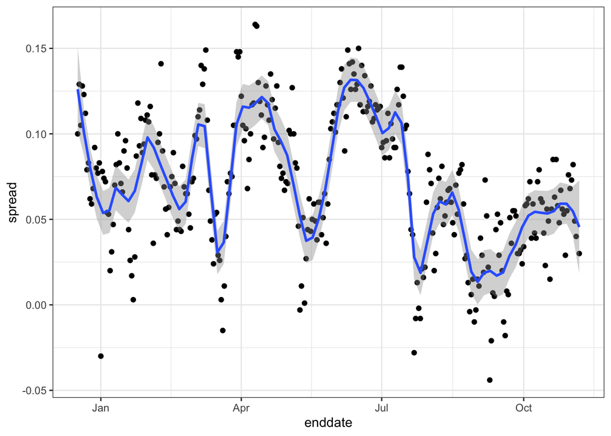

Some of the peaks and valleys we see coincide with events such as the party conventions, which tend to give the candidate a boost. We can see them consistently across several pollsters:

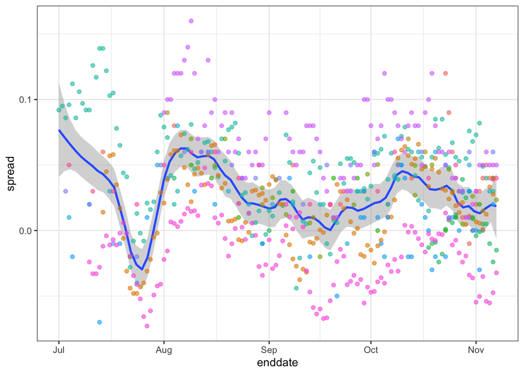

```r
polls_us_election_2016 %>%
  filter(state == "U.S." & enddate>="2016-07-01") %>%
  group_by(pollster) %>%
  filter(n() >= 10) %>%
  ungroup() %>%
  mutate(spread = rawpoll_clinton/100 - rawpoll_trump/100) %>%
  ggplot(aes(enddate, spread)) +
  geom_smooth(method = "loess", span = 0.1) +
  geom_point(aes(color = pollster), show.legend = FALSE, alpha = 0.6)
```

This implies that, if we are going to forecast, our model must include a term that accounts for the time effect. We would write a model including a bias term for time:

$$Y_{ijt} = d + b + h_j + b_t + \varepsilon_{ijt}$$

The standard deviation of $b_t$ would depend on $t$ since the closer we get to election day the smaller this bias term should be.

Pollsters also try to estimate trends, call them $f(t)$, from these data and incorporate these into their predictions.

$$Y_{ijt} = d + b + h_j + b_t + f(t) + \varepsilon_{ijt}$$

We usually see the estimated $f(t)$ not for the difference but for the actual percentages for each candidate:

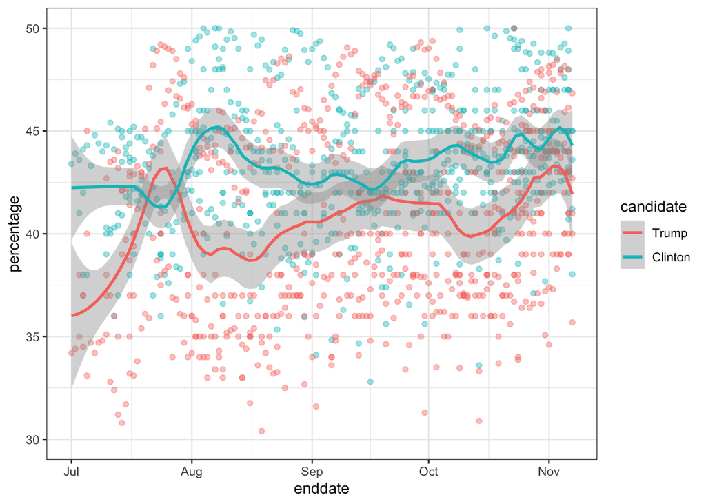

```r
polls_us_election_2016 %>%
  filter(state == "U.S." & enddate>="2016-07-01") %>%
  select(enddate, pollster, rawpoll_clinton, rawpoll_trump) %>%
  rename(Clinton = rawpoll_clinton, Trump = rawpoll_trump) %>%
  gather(candidate, percentage, -enddate, -pollster) %>%
  mutate(candidate = factor(candidate, levels = c("Trump","Clinton")))%>%
  group_by(pollster) %>%
  filter(n() >= 10) %>%
  ungroup() %>%
  ggplot(aes(enddate, percentage, color = candidate)) +
  geom_point(show.legend = FALSE, alpha = 0.4)  +
  geom_smooth(method = "loess", span = 0.15) +
  scale_y_continuous(limits = c(30,50))
```

Once a model, like the one above is selected, we can use historical and present data to estimate all the necessary parameters to make predictions. There are a variety of methods for fitting models which we don’t discuss here.